# RCUK Funding

# Introduction

Links http://www.rcuk.ac.uk/research/efficiency/successrates/

Subjects by research council are described here:

- Arts and Humanities Research Council (AHRC) The AHRC supports research across a wide subject domains including:
- history (ancient, medieval and modern);
- classics;
- archaeology;
- modern languages and linguistics;
- English language and literature;
- the visual arts and media;
- librarianship, information and museum studies;
- philosophy, law, religious studies;
- music and creative and performing arts.
- Biotechnology and Biological Sciences Research Council (BBSRC)

BBSRC funds research in the biosciences, in areas including:

- Genomics, stem cell biology, and bio-nanotechnology, that provide a basis for new technologies in healthcare, food safety, plant and livestock breeding, and bio-processing;
- Whole organism biology relevant to the understanding of diet and health, ageing, animal health and welfare, infectious diseases and immunity, and crop productivity;
- Biological populations and systems that underpin agricultural sustainability, biodiversity and novel bio-based and renewable processes for energy and manufacturing.
- Engineering and Physical Sciences Research Council (EPSRC)

EPSRC supports fundamental research in the physical sciences through to more applied topics in engineering and technology. This includes research in the following areas: * mathematics; * chemistry; * physics; * materials science; * engineering; * computer science, including high performance computing; * energy research; * research into the built environment; * information and communications technology; * research into innovative manufacturing.

- Economic and Social Research Council (ESRC)

ESRC funds social science and economic research across a wide of disciplines encompassing:

- Demography and human geography
- Development studies
- Economics
- History
- Education
- Environmental planning
- Linguistics
- Management and business studies
- Political science and international studies
- Psychology
- Social anthropology
- Social policy
- Social work
- Sociology
- Law and legal studies
- Tools, technologies and methods

Medical Research Council (MRC)

The MRC’s remit covers the full range of medical research from studies of molecules to the implementation of research findings into clinical practice. This includes such topics as:

- the use of animals in research;
- antibiotic resistance;
- brain sciences;
- genomics and proteomics;
- health of the public;
- intensive care;
- patient safety research;
- stem cell research.

Natural Environment Research Council (NERC)

NERC funds environmental research, survey and observation work across a wide spectrum of disciplines, including:

- the geo- and earth sciences, hydrology, soil science, atmospheric research and oceanography;
- biological and microbiological research on animal and plant biodiversity, population dynamics and ecology;
- climate change research;
- environmental chemistry and physics;
- satellite based Earth observation;
- polar research;
- management of land and natural resources.

Science and Technology Facilities Council (STFC)

Amongst others, STFC’s areas of research include:

- astronomy;
- computational science;
- energy;
- nuclear physics;
- particle physics;
- space science.

Source: http://www.rcuk.ac.uk/research/Areas/

# Regional funding data

http://www.rcuk.ac.uk/about/aboutrcs/research-funding-across-the-uk/

# Page

- success rates for grant funding
- http://www.rcuk.ac.uk/research/efficiency/successrates/

Provides separate links to

- http://www.ahrc.ac.uk/about/statistics/competitionstatistics/
- http://www.bbsrc.ac.uk/funding/apply/post_award_overview.html
- http://www.epsrc.ac.uk/funding/successrates/Pages/successrates.aspx
- http://www.esrc.ac.uk/about-us/strategy-and-priorities/demand-management/funding-decisions
- http://www.mrc.ac.uk/documents/xls-csv/success-rates/
- http://www.nerc.ac.uk/funding/application/howtoapply/success/
- http://www.stfc.ac.uk/funding/research-grants/

Not at all standardized

Closest to usable infromation from THES article, 2016 https://www.timeshighereducation.com/news/uk-grant-success-rates-prompt-worldwide-comparisons

Table : overall UK research council success rates

```r
require(tidyverse)
overall_by_council <- tribble(
  ~council_name, ~n_applications, ~n_grants, ~success_pct, ~amount,
  "Arts & Humanities Research Council", 246, 68, 28, 29851958,
  "Biotechnology & Biological Sciences Research Council", 1621, 392, 24, 178719000,
  "Engineering & Physical Sciences Research Council", 2419, 786, 33, 509476006,
  "Economic & Social Research Council", 429, 52, 12, 24107303,
  "Medical Research Council", 1993, 402, 20, 283520000,
  "Natural Environment Research Council", 1036, 311, 30, 86871071
)
# For year 2016
```

Let’s draw this as a neat table

```r
require(knitr)
overall_by_council %>%
  mutate(pct_funding = round(100 * amount / sum(amount), 1)) %>%
  kable(., caption = "UK Research Council Statistics, 2016")
```

| council_name | n_applications | n_grants | success_pct | amount | pct_funding |
| --- | --- | --- | --- | --- | --- |
| Arts & Humanities Research Council | 246 | 68 | 28 | 29851958 | 2.7 |
| Biotechnology & Biological Sciences Research Council | 1621 | 392 | 24 | 178719000 | 16.1 |
| Engineering & Physical Sciences Research Council | 2419 | 786 | 33 | 509476006 | 45.8 |
| Economic & Social Research Council | 429 | 52 | 12 | 24107303 | 2.2 |
| Medical Research Council | 1993 | 402 | 20 | 283520000 | 25.5 |
| Natural Environment Research Council | 1036 | 311 | 30 | 86871071 | 7.8 |

Now to plot this

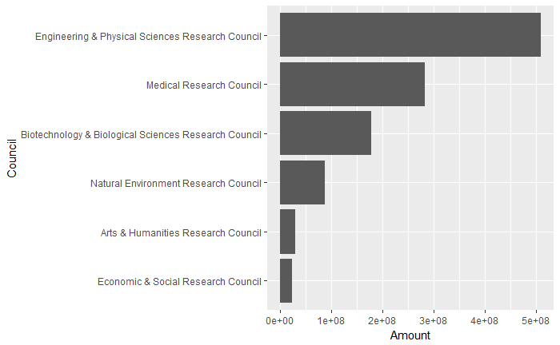

```r
overall_by_council %>%
  ggplot(aes(x = forcats::fct_reorder(council_name, amount), y = amount)) +
  geom_bar(stat = "identity") +
  coord_flip() +
  labs (x = "Council", y = "Amount")
```

Let’s draw mean amounts per grant

```r
overall_by_council %>%
  mutate(mean_grant = amount / n_grants) %>%
  arrange(mean_grant)
```

| council_name | n_applications | n_grants | success_pct | amount | mean_grant |
| --- | --- | --- | --- | --- | --- |
| Natural Environment Research Council | 1036 | 311 | 30 | 86871071 | 279328.2 |
| Arts & Humanities Research Council | 246 | 68 | 28 | 29851958 | 438999.4 |
| Biotechnology & Biological Sciences Research Council | 1621 | 392 | 24 | 178719000 | 455915.8 |
| Economic & Social Research Council | 429 | 52 | 12 | 24107303 | 463602.0 |
| Engineering & Physical Sciences Research Council | 2419 | 786 | 33 | 509476006 | 648188.3 |
| Medical Research Council | 1993 | 402 | 20 | 283520000 | 705273.6 |

Let’s try a treemap

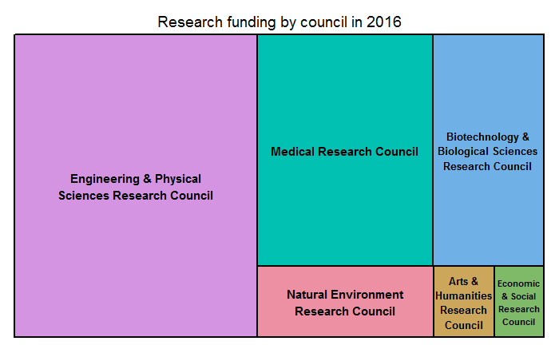

```r
require(treemap)
treemap(
  overall_by_council,
  index = "council_name",
  vSize = "amount",
  title ="Research funding by council in 2016"

)
```

Now research grant success rates

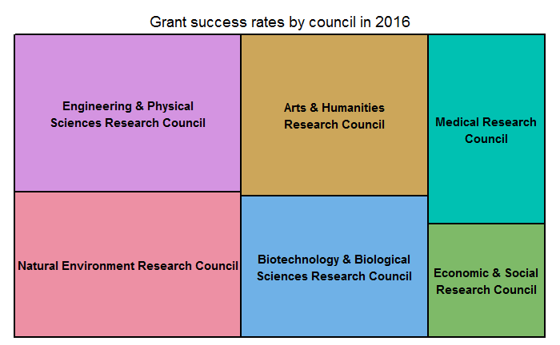

```r
overall_by_council %>%
  mutate(success_rate = n_grants / n_applications) %>%
  treemap(
    .,
    index = "council_name",
    vSize = "success_rate",
    title ="Grant success rates by council in 2016"

)
```

```r
NA
```

Now let’s look at the number of students who enter each subject

We have this data from the following location:

https://www.hesa.ac.uk/news/11-01-2018/sfr247-higher-education-student-statistics/subjects

```r
read_csv(
  "data/sfr247-figure-14 (1).csv",
  skip = 13, col_names = F
  ) -> tmp
tmp[1,1] <- "year"
tmp[1,2:5] <- 2012
tmp[1,6:9] <- 2013
tmp[1, 10:13] <- 2014
tmp[1, 14:17] <- 2015
tmp[1, 18:21] <- 2016
tmp
```

| X1 | X2 | X3 | X4 | X5 | X6 | X7 | X8 | X9 | X10 | X11 | X12 | X13 | X14 | X15 | X16 | X17 | X18 | X19 | X20 | X21 |
| --- | --- | --- | --- | --- | --- | --- | --- | --- | --- | --- | --- | --- | --- | --- | --- | --- | --- | --- | --- | --- |
| year | 2012 | 2012 | 2012 | 2012 | 2013 | 2013 | 2013 | 2013 | 2014 | 2014 | 2014 | 2014 | 2015 | 2015 | 2015 | 2015 | 2016 | 2016 | 2016 | 2016 |
| Subject Area | Female | Male | Other | Total | Female | Male | Other | Total | Female | Male | Other | Total | Female | Male | Other | Total | Female | Male | Other | Total |
| (1) Medicine & dentistry | 37,435 | 29,255 | 0 | 66,690 | 37,875 | 29,480 | 5 | 67,360 | 37,335 | 28,660 | 5 | 66,005 | 37,420 | 28,120 | 10 | 65,550 | 37,430 | 27,645 | 35 | 65,110 |
| (2) Subjects allied to medicine | 222,240 | 57,495 | 10 | 279,745 | 217,185 | 56,035 | 15 | 273,235 | 218,530 | 56,830 | 20 | 275,385 | 226,010 | 58,895 | 25 | 284,935 | 229,905 | 60,770 | 95 | 290,770 |
| (3) Biological sciences | 123,010 | 78,245 | 80 | 201,335 | 126,160 | 81,345 | 15 | 207,520 | 128,775 | 82,570 | 20 | 211,360 | 134,315 | 82,965 | 30 | 217,310 | 142,585 | 83,730 | 85 | 226,395 |
| (4) Veterinary science | 4,350 | 1,410 | 0 | 5,760 | 4,515 | 1,420 | 0 | 5,935 | 4,495 | 1,405 | 0 | 5,900 | 5,205 | 1,570 | 0 | 6,775 | 5,520 | 1,625 | 0 | 7,145 |
| (5) Agriculture & related subjects | 11,455 | 7,505 | 0 | 18,960 | 11,010 | 7,350 | 0 | 18,360 | 11,855 | 7,350 | 0 | 19,205 | 11,805 | 7,220 | 0 | 19,025 | 11,815 | 6,835 | 5 | 18,655 |
| (6) Physical sciences | 37,045 | 55,790 | 5 | 92,840 | 36,910 | 56,345 | 10 | 93,270 | 37,080 | 56,660 | 15 | 93,760 | 38,305 | 56,590 | 30 | 94,920 | 39,200 | 55,925 | 45 | 95,170 |
| (7) Mathematical sciences | 16,325 | 25,850 | 5 | 42,185 | 16,025 | 26,195 | 5 | 42,225 | 15,955 | 26,440 | 5 | 42,405 | 16,065 | 27,080 | 10 | 43,155 | 16,265 | 27,580 | 35 | 43,880 |
| (8) Computer science | 15,530 | 73,945 | 5 | 89,480 | 15,645 | 75,910 | 10 | 91,565 | 16,040 | 77,170 | 20 | 93,230 | 16,505 | 79,735 | 20 | 96,260 | 17,390 | 83,710 | 45 | 101,145 |

[output cut: 14 more lines]

```r
tmp2 <- tmp[-1,]
names(tmp2) <- tmp[1,]
tmp2
```

| year | 2012 | 2012 | 2012 | 2012 | 2013 | 2013 | 2013 | 2013 | 2014 | 2014 | 2014 | 2014 | 2015 | 2015 | 2015 | 2015 | 2016 | 2016 | 2016 | 2016 |
| --- | --- | --- | --- | --- | --- | --- | --- | --- | --- | --- | --- | --- | --- | --- | --- | --- | --- | --- | --- | --- |
| Subject Area | Female | Male | Other | Total | Female | Male | Other | Total | Female | Male | Other | Total | Female | Male | Other | Total | Female | Male | Other | Total |
| (1) Medicine & dentistry | 37,435 | 29,255 | 0 | 66,690 | 37,875 | 29,480 | 5 | 67,360 | 37,335 | 28,660 | 5 | 66,005 | 37,420 | 28,120 | 10 | 65,550 | 37,430 | 27,645 | 35 | 65,110 |
| (2) Subjects allied to medicine | 222,240 | 57,495 | 10 | 279,745 | 217,185 | 56,035 | 15 | 273,235 | 218,530 | 56,830 | 20 | 275,385 | 226,010 | 58,895 | 25 | 284,935 | 229,905 | 60,770 | 95 | 290,770 |
| (3) Biological sciences | 123,010 | 78,245 | 80 | 201,335 | 126,160 | 81,345 | 15 | 207,520 | 128,775 | 82,570 | 20 | 211,360 | 134,315 | 82,965 | 30 | 217,310 | 142,585 | 83,730 | 85 | 226,395 |
| (4) Veterinary science | 4,350 | 1,410 | 0 | 5,760 | 4,515 | 1,420 | 0 | 5,935 | 4,495 | 1,405 | 0 | 5,900 | 5,205 | 1,570 | 0 | 6,775 | 5,520 | 1,625 | 0 | 7,145 |
| (5) Agriculture & related subjects | 11,455 | 7,505 | 0 | 18,960 | 11,010 | 7,350 | 0 | 18,360 | 11,855 | 7,350 | 0 | 19,205 | 11,805 | 7,220 | 0 | 19,025 | 11,815 | 6,835 | 5 | 18,655 |
| (6) Physical sciences | 37,045 | 55,790 | 5 | 92,840 | 36,910 | 56,345 | 10 | 93,270 | 37,080 | 56,660 | 15 | 93,760 | 38,305 | 56,590 | 30 | 94,920 | 39,200 | 55,925 | 45 | 95,170 |
| (7) Mathematical sciences | 16,325 | 25,850 | 5 | 42,185 | 16,025 | 26,195 | 5 | 42,225 | 15,955 | 26,440 | 5 | 42,405 | 16,065 | 27,080 | 10 | 43,155 | 16,265 | 27,580 | 35 | 43,880 |
| (8) Computer science | 15,530 | 73,945 | 5 | 89,480 | 15,645 | 75,910 | 10 | 91,565 | 16,040 | 77,170 | 20 | 93,230 | 16,505 | 79,735 | 20 | 96,260 | 17,390 | 83,710 | 45 | 101,145 |
| (9) Engineering & technology | 24,935 | 133,000 | 30 | 157,960 | 25,580 | 133,405 | 25 | 159,010 | 26,955 | 134,340 | 20 | 161,315 | 27,760 | 135,465 | 30 | 163,255 | 29,025 | 136,085 | 45 | 165,155 |

[output cut: 13 more lines]

```r
dta_tidy <- bind_rows(
  tmp %>% (function(..){
    .. %>%
    select(X1:X5) %>% mutate(year = 2012) %>% slice(-c(1,2)) -> ..
    names(..) <- c("subject", "female", "male", "other", "total", "year")
    ..
  }),
  tmp %>% (function(..){
    .. %>%
      select(X1, X6:X9) %>% mutate(year = 2013) %>% slice(-c(1,2)) -> ..
    names(..) <- c("subject", "female", "male", "other", "total", "year")
    ..
  }),
  tmp %>% (function(..){
    .. %>%
      select(X1, X10:X13) %>% mutate(year = 2014) %>% slice(-c(1,2)) -> ..
    names(..) <- c("subject", "female", "male", "other", "total", "year")
    ..
  }),
  tmp %>% (function(..){
    .. %>%
      select(X1, X10:X13) %>% mutate(year = 2014) %>% slice(-c(1,2)) -> ..
    names(..) <- c("subject", "female", "male", "other", "total", "year")
    ..
  }),
  tmp %>% (function(..){
    .. %>%
      select(X1, X14:X17) %>% mutate(year = 2015) %>% slice(-c(1,2)) -> ..
    names(..) <- c("subject", "female", "male", "other", "total", "year")
    ..
  }),
    tmp %>% (function(..){
    .. %>%
      select(X1, X18:X21) %>% mutate(year = 2016) %>% slice(-c(1,2)) -> ..
    names(..) <- c("subject", "female", "male", "other", "total", "year")
    ..
  })
) %>%
  gather(female:total, key = gender, value = "number") %>%
  mutate(number = number %>%
           stringr::str_replace(",", "") %>%
           as.numeric
  )
```

```
NAs introduced by coercion
```

Now to get a lookup for students to research council

```r
subject_council_lookup <- tribble(
  ~subject_name, ~council,
"(1) Medicine & dentistry", "mrc",
"(2) Subjects allied to medicine", "mrc",
"(3) Biological sciences", "bbsrc",
"(4) Veterinary science", "nerc",
"(5) Agriculture & related subjects", "nerc",
"(6) Physical sciences", "epsrc",
"(7) Mathematical sciences", "epsrc",
"(8) Computer science", "epsrc",
"(9) Engineering & technology", "epsrc",
"(A) Architecture, building & planning", "esrc",
"(B) Social studies", "esrc",
"(C) Law", "esrc",
"(D) Business & administrative studies", "esrc",
"(E) Mass communications & documentation", "esrc",
"(F) Languages", "ahrc",
"(G) Historical & philosophical studies", "arhc",
"(H) Creative arts & design", "ahrc",
"(I) Education", "esrc",
"(J) Combined", NA
)
council_abbreviation_lookup <- tribble(
  ~abbreviation, ~full_name,
  "mrc","Medical Research Council",
  "esrc", "Economic & Social Research Council",
  "epsrc","Engineering & Physical Sciences Research Council",
  "nerc","Natural Environment Research Council",
  "ahrc", "Arts & Humanities Research Council",
  "bbsrc","Biotechnology & Biological Sciences Research Council"
)
```

Now let’s try to join the data

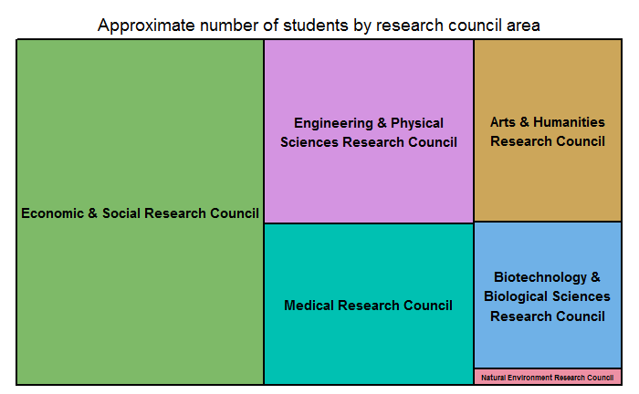

```r
subject_council_lookup %>%
  inner_join(
    dta_tidy %>%
      filter(year == 2016) %>%
      filter(gender == "total"),
    by = c("subject_name"="subject")
    ) %>%
  group_by(council) %>%
  summarise(number = sum(number, na.rm = T)) %>%
  filter(!is.na(council)) %>%
  inner_join(
    council_abbreviation_lookup,
    by = c("council"="abbreviation")
  ) %>%
  treemap(
    .,
    index = "full_name",
    vSize = "number",
    title ="Approximate number of students by research council area"

  )
```

```r
NA
```

Now let’s look at association

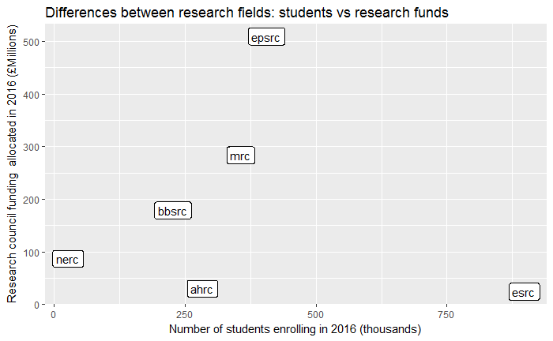

```r
subject_council_lookup %>%
  inner_join(
    dta_tidy %>%
      filter(year == 2016) %>%
      filter(gender == "total"),
    by = c("subject_name"="subject")
    ) %>%
  group_by(council) %>%
  summarise(number = sum(number, na.rm = T)) %>%
  filter(!is.na(council)) %>%
  inner_join(
    council_abbreviation_lookup,
    by = c("council"="abbreviation")
  ) %>%
  left_join(
    overall_by_council %>% select(council_name, research_funding = amount),
    by = c("full_name"="council_name")
  ) %>%
  select(
    council_name = full_name,
    number_of_students = number,
    research_funding
  ) %>%
  left_join(
    council_abbreviation_lookup,
    by = c("council_name"="full_name")
  ) %>%
  mutate(research_funding = research_funding / 1000000) %>%
  mutate(number_of_students = number_of_students / 1000) %>%
  ggplot(aes(x = number_of_students, y = research_funding, label = abbreviation)) +
  geom_label() +
  labs(y = "Research council funding  allocated in 2016 (£Millions)",
         x = "Number of students enrolling in 2016 (thousands)",
       title = "Differences between research fields: students vs research funds"
  )
```

Subjects by research council are described here:

Arts and Humanities Research Council (AHRC) The AHRC supports research across a wide subject domains including:

history (ancient, medieval and modern); classics; archaeology; modern languages and linguistics; English language and literature; the visual arts and media; librarianship, information and museum studies; philosophy, law, religious studies; music and creative and performing arts.

Biotechnology and Biological Sciences Research Council (BBSRC) BBSRC funds research in the biosciences, in areas including: Genomics, stem cell biology, and bio-nanotechnology, that provide a basis for new technologies in healthcare, food safety, plant and livestock breeding, and bio-processing; Whole organism biology relevant to the understanding of diet and health, ageing, animal health and welfare, infectious diseases and immunity, and crop productivity; Biological populations and systems that underpin agricultural sustainability, biodiversity and novel bio-based and renewable processes for energy and manufacturing.

Engineering and Physical Sciences Research Council (EPSRC) EPSRC supports fundamental research in the physical sciences through to more applied topics in engineering and technology. This includes research in the following areas: mathematics; chemistry; physics; materials science; engineering; computer science, including high performance computing; energy research; research into the built environment; information and communications technology; research into innovative manufacturing.

Economic and Social Research Council (ESRC) ESRC funds social science and economic research across a wide of disciplines encompassing: Demography and human geography Development studies Economics History Education Environmental planning Linguistics Management and business studies Political science and international studies Psychology Social anthropology Social policy Social work Sociology Law and legal studies Tools, technologies and methods

Medical Research Council (MRC) The MRC’s remit covers the full range of medical research from studies of molecules to the implementation of research findings into clinical practice. This includes such topics as: the use of animals in research; antibiotic resistance; brain sciences; genomics and proteomics; health of the public; intensive care; patient safety research; stem cell research.

Natural Environment Research Council (NERC) NERC funds environmental research, survey and observation work across a wide spectrum of disciplines, including: the geo- and earth sciences, hydrology, soil science, atmospheric research and oceanography; biological and microbiological research on animal and plant biodiversity, population dynamics and ecology; climate change research; environmental chemistry and physics; satellite based Earth observation; polar research; management of land and natural resources.

Science and Technology Facilities Council (STFC) Amongst others, STFC’s areas of research include: astronomy; computational science; energy; nuclear physics; particle physics; space science.

Source: http://www.rcuk.ac.uk/research/Areas/